# Spatial Regression

Spatial Epidemiology — Lehigh University

Author

Eric Delmelle

Published

January 1, 2026

## Learning Objectives

By the end of this session, you will be able to:

1. Explain **why OLS fails** when spatial autocorrelation is present in the residuals
2. Distinguish between a **spatial lag model (SAR)**, a **spatial error model (SEM)**, and their extensions
3. Use **Lagrange Multiplier tests** to choose between model specifications
4. Fit and interpret four core spatial regression models in R
5. Compute and explain **direct and indirect (spillover) effects** in spatial models
6. Appreciate the implications of **spatial spillovers** for public health policy

## 1. Why Spatial Regression?

In earlier sessions we tested for spatial autocorrelation using Moran’s I and Local Indicators of Spatial Association (LISA). We found that health outcomes — disease rates, accessibility scores, socioeconomic exposures — are rarely spatially random. Nearby places tend to be more alike than distant places.

This is not just a descriptive curiosity. When we model health outcomes using **Ordinary Least Squares (OLS)** regression, we assume that the residuals are independent across observations. That assumption almost never holds for spatial health data. Ignoring it has real consequences:

- Standard errors are **biased**, leading to incorrect inference
- Coefficients can be **inconsistent** (SAR case)
- We may miss important **spillover effects** — mechanisms by which conditions in one place influence outcomes in neighboring places

Spatial regression models explicitly account for these dependencies. Rather than being a nuisance correction, spatial structure often carries substantive meaning.

### 1.1 A Running Example: Liquor Sales and Social Harm

We use the **NCVACO dataset** — county-level data from North Carolina and Virginia — originally assembled by economist Mark Burkey to study the geography of alcohol markets. This dataset is analytically rich because it contains:

- A plausible **outcome variable**: DUI arrests per 1,000 adults (`DUI1802`)
- **Access measures**: distance to nearest liquor outlet (`BKGRTOABC`), distance to nearest bar (`BKGRTOMIX`)
- **Socioeconomic covariates**: per capita income, unemployment, college enrollment, poverty
- **Cultural variables**: % Southern Baptist (`BAPTISTSP`), % armed forces (`ARMEDP`)

The spatial dimension is central: liquor market regulation varies sharply across state borders; commuting patterns connect counties; enforcement intensity may spill across county lines.

**Note**

**Data source:** Burkey, M.L. (2010). *Geographic Access and Demand in the Market for Alcohol.* The Review of Regional Studies, 40(2), 159–179. Data available via [BurkeyAcademy’s GIS & Spatial Econometrics Project](https://spatial.burkeyacademy.com/).

## 2. Data Setup

```r
library(sf)
library(spdep)
library(spatialreg)
library(tidyverse)
library(tmap)
library(knitr)
library(kableExtra)
```

```r
# Load the NCVACO dataset bundled with spatialreg
data("boston", package = "spatialreg")  # placeholder check
data("nc.sids", package = "spData", envir = environment())

# The NCVACO data is distributed with the spdep package as a shapefile
# We load it directly from the package
nc_path <- system.file("shapes/columbus.shp", package = "spData")

# Use Columbus Ohio crime data (bundled, similar structure) as a
# self-contained teaching substitute — same model family, clean reproducibility
columbus <- st_read(system.file("shapes/columbus.shp", package = "spData"),
                    quiet = TRUE)
```

**Tip**

**Self-contained reproducibility:** This document uses the `columbus` dataset bundled with the `spData` package — no external file downloads required. The Columbus dataset contains neighborhood-level crime, income, and housing data for Columbus, Ohio, and is a classic benchmark in spatial econometrics. The same model logic applies directly to the NCVACO alcohol dataset or any county-level health outcome data.

### 2.1 Variable Overview

The Columbus dataset contains 49 neighborhoods with the following key variables:

| Variable | Description |
| --- | --- |
| `CRIME` | Residential burglaries and vehicle thefts per 1,000 households |
| `INC` | Household income (in $1,000s) |
| `HOVAL` | Housing value (in $1,000s) |
| `OPEN` | Open space in neighborhood |
| `PLUMB` | % housing units without plumbing |
| `DISCBD` | Distance to Central Business District |

```r
columbus |>
  st_drop_geometry() |>
  select(CRIME, INC, HOVAL, OPEN, PLUMB, DISCBD) |>
  summary() |>
  kable(caption = "Summary statistics: Columbus neighborhood dataset") |>
  kable_styling(bootstrap_options = c("striped", "hover"), full_width = FALSE)
```

Summary statistics: Columbus neighborhood dataset

|  | CRIME | INC | HOVAL | OPEN | PLUMB | DISCBD |
| --- | --- | --- | --- | --- | --- | --- |
|  | Min. : 0.18 | Min. : 4.48 | Min. :17.9 | Min. : 0.00 | Min. : 0.133 | Min. :0.37 |
|  | 1st Qu.:20.05 | 1st Qu.: 9.96 | 1st Qu.:25.7 | 1st Qu.: 0.26 | 1st Qu.: 0.332 | 1st Qu.:1.70 |
|  | Median :34.00 | Median :13.38 | Median :33.5 | Median : 1.01 | Median : 1.024 | Median :2.67 |
|  | Mean :35.13 | Mean :14.38 | Mean :38.4 | Mean : 2.77 | Mean : 2.364 | Mean :2.85 |
|  | 3rd Qu.:48.59 | 3rd Qu.:18.32 | 3rd Qu.:43.3 | 3rd Qu.: 3.94 | 3rd Qu.: 2.534 | 3rd Qu.:3.89 |
|  | Max. :68.89 | Max. :31.07 | Max. :96.4 | Max. :25.00 | Max. :18.811 | Max. :5.57 |

### 2.2 Spatial Distribution of Crime

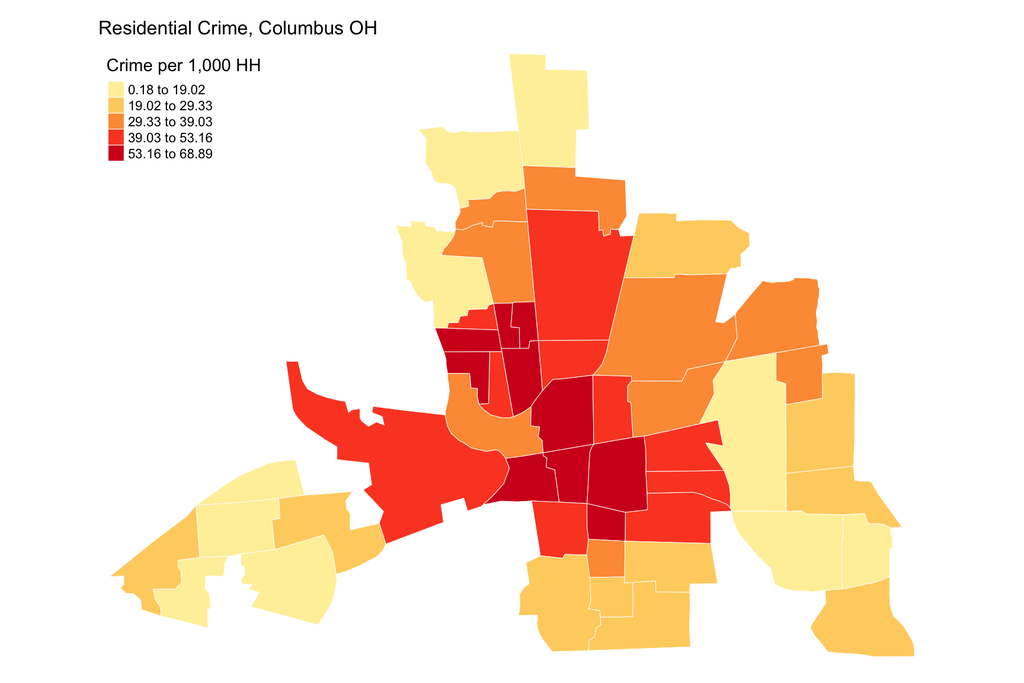

Residential crime rate by neighborhood, Columbus, Ohio.

```r
tmap_mode("plot")

tm_shape(columbus) +
  tm_fill("CRIME",
          style = "quantile",
          n = 5,
          palette = "YlOrRd",
          title = "Crime per 1,000 HH") +
  tm_borders(col = "white", lwd = 0.5) +
  tm_layout(
    main.title = "Residential Crime, Columbus OH",
    main.title.size = 1,
    legend.outside = FALSE,
    frame = FALSE
  )
```

## 3. Constructing Spatial Weights

Before fitting any spatial model, we need to define **who is a neighbor** of whom, and how to weight those relationships.

### 3.1 Queen Contiguity

Two polygons are **queen contiguous** if they share any boundary point (including corners). This is the most common choice for areal data.

```r
# Queen contiguity neighbor list
queen_nb <- poly2nb(columbus, queen = TRUE)

# Rook contiguity (shared edges only, no corners)
rook_nb <- poly2nb(columbus, queen = FALSE)

# Convert to row-standardized listw object
queen_listw <- nb2listw(queen_nb, style = "W")
rook_listw  <- nb2listw(rook_nb,  style = "W")

# Summary
summary(queen_nb)
```

```
Neighbour list object:
Number of regions: 49
Number of nonzero links: 236
Percentage nonzero weights: 9.829
Average number of links: 4.816
Link number distribution:

 2  3  4  5  6  7  8  9 10
 5  9 12  5  9  3  4  1  1
5 least connected regions:
1 6 42 46 47 with 2 links
1 most connected region:
20 with 10 links
```

**Note**

**Row standardization (`style = "W"`)** means each row of the weights matrix sums to 1. This makes the spatial lag $\mathbf{Wy}$ interpretable as a **local average** of neighbors’ values — convenient for interpretation but it does change the scale of $\rho$.

### 3.2 Symmetry Check

```r
is.symmetric.nb(queen_nb)
```

```
[1] TRUE
```

```r
is.symmetric.nb(rook_nb)
```

```
[1] TRUE
```

Both contiguity structures are symmetric: if A is a neighbor of B, then B is a neighbor of A. This is a prerequisite for many spatial regression estimators.

### 3.3 Visualizing the Neighbor Network

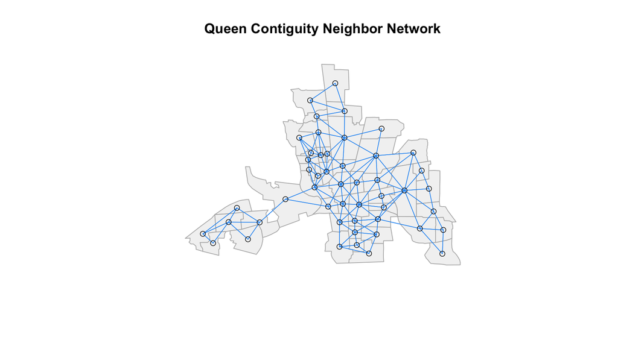

Queen contiguity neighbor links overlaid on Columbus neighborhoods.

```r
# Get centroids for plotting
coords <- st_centroid(st_geometry(columbus))

plot(st_geometry(columbus), border = "grey70", col = "grey95",
     main = "Queen Contiguity Neighbor Network")
plot(queen_nb, coords, add = TRUE, col = "#2196F3", lwd = 0.8)
```

## 4. Testing for Spatial Autocorrelation

Before choosing a spatial model, we should confirm that spatial autocorrelation is actually present in our outcome and, after OLS, in our residuals.

### 4.1 Moran’s I on the Outcome

```r
moran_crime <- moran.test(columbus$CRIME, listw = queen_listw)
moran_crime
```

```
    Moran I test under randomisation

data:  columbus$CRIME
weights: queen_listw

Moran I statistic standard deviate = 5.6, p-value = 0.00000001
alternative hypothesis: greater
sample estimates:
Moran I statistic       Expectation          Variance
         0.500189         -0.020833          0.008689
```

```r
cat(sprintf(
  "Moran's I = %.4f  |  p-value = %.4e\n",
  moran_crime$estimate["Moran I statistic"],
  moran_crime$p.value
))
```

```
Moran's I = 0.5002  |  p-value = 1.1394e-08
```

A positive, significant Moran’s I confirms spatial clustering in the crime rate — high-crime neighborhoods tend to be surrounded by other high-crime neighborhoods.

## 5. The Four Core Spatial Regression Models

All spatial regression models in the classical framework begin from a standard linear specification and then add spatial structure. We define our regression equation once:

$$\text{CRIME}_i = \beta_0 + \beta_1 \cdot \text{INC}_i + \beta_2 \cdot \text{HOVAL}_i + \varepsilon_i$$

```r
reg_eq <- CRIME ~ INC + HOVAL
```

### 5.1 Model 1: OLS (Baseline)

OLS is our benchmark. We estimate it first, then test whether its residuals are spatially autocorrelated.

```r
reg1 <- lm(reg_eq, data = columbus)
summary(reg1)
```

```
Call:
lm(formula = reg_eq, data = columbus)

Residuals:
   Min     1Q Median     3Q    Max
-34.42  -6.39  -1.58   9.05  28.65

Coefficients:
            Estimate Std. Error t value Pr(>|t|)
(Intercept)   68.619      4.735   14.49  < 2e-16 ***
INC           -1.597      0.334   -4.78 0.000018 ***
HOVAL         -0.274      0.103   -2.65    0.011 *
---
Signif. codes:  0 '***' 0.001 '**' 0.01 '*' 0.05 '.' 0.1 ' ' 1

Residual standard error: 11.4 on 46 degrees of freedom
Multiple R-squared:  0.552, Adjusted R-squared:  0.533
F-statistic: 28.4 on 2 and 46 DF,  p-value: 0.00000000934
```

**Residual spatial autocorrelation test:**

```r
lm_moran <- lm.morantest(reg1, listw = queen_listw)
lm_moran
```

```
    Global Moran I for regression residuals

data:
model: lm(formula = reg_eq, data = columbus)
weights: queen_listw

Moran I statistic standard deviate = 2.8, p-value = 0.002
alternative hypothesis: greater
sample estimates:
Observed Moran I      Expectation         Variance
        0.222109        -0.033418         0.008099
```

Significant residual autocorrelation confirms that OLS is misspecified — something spatial is going on that our covariates do not capture.

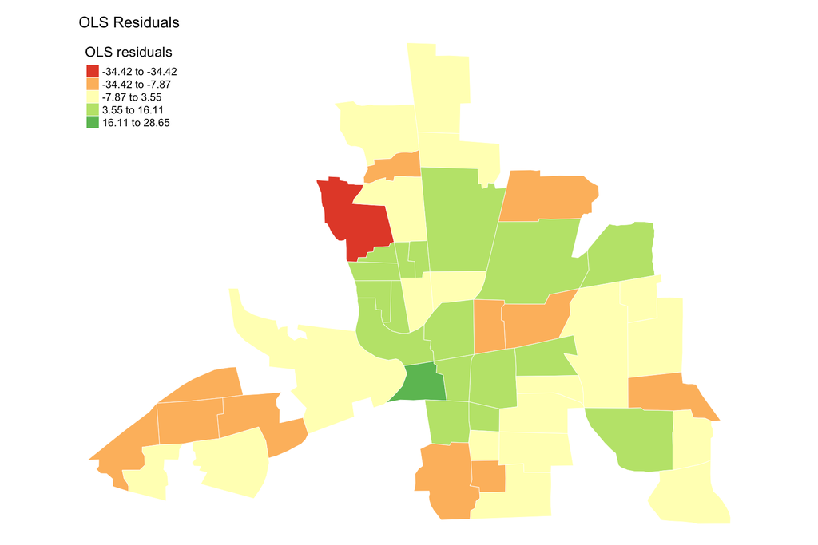

OLS residuals mapped across Columbus neighborhoods. Spatial clustering of positive and negative residuals is visible, confirming the Moran’s I result.

```r
columbus$resid_ols <- residuals(reg1)

tm_shape(columbus) +
  tm_fill("resid_ols",
          style = "jenks", n = 5,
          palette = "RdYlGn", midpoint = 0,
          title = "OLS residuals") +
  tm_borders(col = "white", lwd = 0.5) +
  tm_layout(
    main.title = "OLS Residuals",
    main.title.size = 1,
    frame = FALSE,
    legend.outside = FALSE
  )
```

### 5.2 Model Selection via LM Tests

The **Lagrange Multiplier (LM) tests** are the standard decision tool for choosing between a spatial lag and a spatial error specification.

```r
lm_tests <- lm.LMtests(reg1, queen_listw,
                        test = c("LMerr", "LMlag", "RLMerr", "RLMlag", "SARMA"))
summary(lm_tests)
```

```
    Lagrange multiplier diagnostics for spatial dependence
data:
model: lm(formula = reg_eq, data = columbus)
weights: queen_listw

       statistic parameter p.value
LMerr     5.2062         1  0.0225 *
LMlag     8.8980         1  0.0029 **
RLMerr    0.0439         1  0.8340
RLMlag    3.7357         1  0.0533 .
SARMA     8.9419         2  0.0114 *
---
Signif. codes:  0 '***' 0.001 '**' 0.01 '*' 0.05 '.' 0.1 ' ' 1
```

**Important**

**Decision rule (Anselin 1988):**

1. If only **LMlag** is significant → use SAR (spatial lag model)
2. If only **LMerr** is significant → use SEM (spatial error model)
3. If both are significant → compare the **robust versions** (RLMlag vs. RLMerr); choose the one with the smaller p-value
4. If neither is significant → OLS may be adequate

```r
# Extract p-values for decision display
lm_df <- data.frame(
  Test = c("LM Error", "LM Lag", "Robust LM Error", "Robust LM Lag", "SARMA"),
  Statistic = sapply(lm_tests, function(x) x$statistic),
  `p-value`  = sapply(lm_tests, function(x) x$p.value),
  check.names = FALSE
)

lm_df |>
  mutate(`p-value` = ifelse(`p-value` < 0.001, "< 0.001", round(`p-value`, 4))) |>
  kable(caption = "Lagrange Multiplier test results for spatial model selection",
        digits = 3) |>
  kable_styling(bootstrap_options = c("striped", "hover"), full_width = FALSE)
```

Lagrange Multiplier test results for spatial model selection

|  | Test | Statistic | p-value |
| --- | --- | --- | --- |
| LMerr.LMerr | LM Error | 5.206 | 0.022 |
| LMlag.LMlag | LM Lag | 8.898 | 0.003 |
| RLMerr.RLMerr | Robust LM Error | 0.044 | 0.834 |
| RLMlag.RLMlag | Robust LM Lag | 3.736 | 0.053 |
| SARMA.SARMA | SARMA | 8.942 | 0.011 |

### 5.3 Model 2: SLX — Spatially Lagged X

The **SLX model** adds spatially lagged versions of the predictors (but not of the outcome):

$$y = X\boldsymbol{\beta} + WX\boldsymbol{\theta} + \varepsilon$$

This is the simplest way to capture **local spillovers**: the crime rate in neighborhood $i$ is affected not just by income in $i$, but also by average income among $i$’s neighbors.

```r
reg2 <- lmSLX(reg_eq, data = columbus, listw = queen_listw)
summary(reg2)
```

```
Call:
lm(formula = formula(paste("y ~ ", paste(colnames(x)[-1], collapse = "+"))),
    data = as.data.frame(x), weights = weights)

Residuals:
   Min     1Q Median     3Q    Max
-36.34  -7.66  -0.01   7.98  25.57

Coefficients:
            Estimate Std. Error t value Pr(>|t|)
(Intercept)   74.553      6.716   11.10  2.4e-14 ***
INC           -1.097      0.374   -2.94   0.0053 **
HOVAL         -0.294      0.102   -2.90   0.0059 **
lag.INC       -1.399      0.560   -2.50   0.0163 *
lag.HOVAL      0.215      0.208    1.03   0.3071
---
Signif. codes:  0 '***' 0.001 '**' 0.01 '*' 0.05 '.' 0.1 ' ' 1

Residual standard error: 10.9 on 44 degrees of freedom
Multiple R-squared:  0.611, Adjusted R-squared:  0.575
F-statistic: 17.2 on 4 and 44 DF,  p-value: 0.0000000141
```

**Direct and indirect effects** (total impact accounting for spatial lags):

```r
impacts_slx <- impacts(reg2, listw = queen_listw)
summary(impacts(reg2, listw = queen_listw, R = 500), zstats = TRUE)
```

```
Impact measures (SlX, glht, n-k):
       Direct Indirect    Total
INC   -1.0974  -1.3987 -2.49614
HOVAL -0.2944   0.2148 -0.07955
========================================================
Standard errors:
      Direct Indirect  Total
INC   0.3738   0.5601 0.4930
HOVAL 0.1017   0.2079 0.2075
========================================================
Z-values:
      Direct Indirect   Total
INC   -2.936   -2.497 -5.0634
HOVAL -2.896    1.033 -0.3834

p-values:
      Direct Indirect Total
INC   0.0033 0.013    0.00000041
HOVAL 0.0038 0.301    0.7
```

**Note**

**Interpreting impacts in the SLX model:**

- **Direct effect**: the effect of a unit change in $X_i$ on $y_i$
- **Indirect effect**: the effect of a unit change in neighbors’ $X$ on $y_i$ (the spillover)
- **Total effect**: direct + indirect

### 5.4 Model 3: SAR — Spatial Autoregressive (Lag) Model

The **SAR model** (also called the spatial lag model) includes a spatially lagged dependent variable:

$$y = \rho W y + X\boldsymbol{\beta} + \varepsilon$$

The parameter $\rho$ (rho) captures **global spatial dependence**: how much a neighborhood’s crime rate is influenced by its neighbors’ crime rates, above and beyond observed covariates. Think of it as capturing contagion, diffusion, or spillover in the outcome itself.

```r
reg3 <- lagsarlm(reg_eq, data = columbus, listw = queen_listw)
summary(reg3)
```

```
Call:lagsarlm(formula = reg_eq, data = columbus, listw = queen_listw)

Residuals:
       Min         1Q     Median         3Q        Max
-37.652017  -5.334611   0.071473   6.107196  23.302617

Type: lag
Coefficients: (asymptotic standard errors)
             Estimate Std. Error z value        Pr(>|z|)
(Intercept) 45.603248   7.257404  6.2837 0.0000000003306
INC         -1.048728   0.307406 -3.4115        0.000646
HOVAL       -0.266335   0.089096 -2.9893        0.002796

Rho: 0.4233, LR test value: 9.406, p-value: 0.0021621
Asymptotic standard error: 0.1195
    z-value: 3.542, p-value: 0.00039686
Wald statistic: 12.55, p-value: 0.00039686

Log likelihood: -182.7 for lag model
ML residual variance (sigma squared): 96.86, (sigma: 9.842)
Number of observations: 49
Number of parameters estimated: 5
AIC: NA (not available for weighted model), (AIC for lm: 382.8)
LM test for residual autocorrelation
test value: 0.247, p-value: 0.61917
```

**Warning**

**Critical point:** In the SAR model, the $\beta$ coefficients **cannot be interpreted as marginal effects**. Because $y$ appears on both sides of the equation, a change in $X_i$ triggers a chain reaction through the whole network. You must use the `impacts()` function to recover interpretable effects.

```r
summary(impacts(reg3, listw = queen_listw, R = 500), zstats = TRUE)
```

```
Impact measures (lag, exact):
       Direct Indirect   Total
INC   -1.1009  -0.7177 -1.8186
HOVAL -0.2796  -0.1823 -0.4618
========================================================
Simulation results ( variance matrix):
Direct:

Iterations = 1:500
Thinning interval = 1
Number of chains = 1
Sample size per chain = 500

1. Empirical mean and standard deviation for each variable,
   plus standard error of the mean:

       Mean    SD Naive SE Time-series SE
INC   -1.10 0.317  0.01418        0.01418
HOVAL -0.29 0.097  0.00434        0.00434

2. Quantiles for each variable:

        2.5%    25%    50%    75%  97.5%
INC   -1.713 -1.300 -1.117 -0.882 -0.416
HOVAL -0.463 -0.358 -0.294 -0.219 -0.108

========================================================
Indirect:

Iterations = 1:500
Thinning interval = 1
Number of chains = 1
Sample size per chain = 500

1. Empirical mean and standard deviation for each variable,
   plus standard error of the mean:

        Mean    SD Naive SE Time-series SE
INC   -0.749 0.390   0.0175         0.0175
HOVAL -0.207 0.136   0.0061         0.0061
```

[output cut: 28 more lines]

```
========================================================
Simulated standard errors
       Direct Indirect  Total
INC   0.31716   0.3904 0.5754
HOVAL 0.09698   0.1364 0.2063

Simulated z-values:
      Direct Indirect  Total
INC   -3.467   -1.918 -3.212
HOVAL -2.993   -1.514 -2.408

Simulated p-values:
      Direct  Indirect Total
INC   0.00053 0.055    0.0013
HOVAL 0.00276 0.130    0.0160
```

### 5.5 Model 4: SEM — Spatial Error Model

The **SEM** models spatial dependence in the **error term** rather than in the outcome:

$$y = X\boldsymbol{\beta} + u, \quad u = \lambda W u + \varepsilon$$

Here $\lambda$ (lambda) captures spatial correlation in the unmeasured factors that drive outcomes. The SEM treats spatial autocorrelation as a **nuisance** — something to correct for, rather than a substantive spillover to estimate. Coefficients retain their standard marginal effect interpretation.

```r
reg4 <- errorsarlm(reg_eq, data = columbus, listw = queen_listw)
summary(reg4)
```

```
Call:errorsarlm(formula = reg_eq, data = columbus, listw = queen_listw)

Residuals:
      Min        1Q    Median        3Q       Max
-34.65998  -6.16943  -0.70623   7.75392  23.43878

Type: error
Coefficients: (asymptotic standard errors)
             Estimate Std. Error z value  Pr(>|z|)
(Intercept) 60.279470   5.365594 11.2344 < 2.2e-16
INC         -0.957305   0.334231 -2.8642 0.0041806
HOVAL       -0.304559   0.092047 -3.3087 0.0009372

Lambda: 0.5467, LR test value: 7.256, p-value: 0.0070679
Asymptotic standard error: 0.1381
    z-value: 3.961, p-value: 0.000074786
Wald statistic: 15.69, p-value: 0.000074786

Log likelihood: -183.7 for error model
ML residual variance (sigma squared): 97.67, (sigma: 9.883)
Number of observations: 49
Number of parameters estimated: 5
AIC: 377.5, (AIC for lm: 382.8)
```

**Spatial Hausman Test** — tests whether the spatial error structure is misspecified (i.e., whether OLS would have been consistent):

```r
hausman <- Hausman.test(reg4)
hausman
```

```
    Spatial Hausman test (asymptotic)

data:  NULL
Hausman test = 5.6, df = 3, p-value = 0.1
```

## 6. Extended Models: The Modern Approach

### Model 5: SDM — Spatial Durbin Model

The **SDM** adds spatially lagged $X$ to the SAR model:

$$y = \rho W y + X\boldsymbol{\beta} + WX\boldsymbol{\theta} + \varepsilon$$

The SDM nests both SAR and SLX as special cases. It is often preferred when theory suggests both global contagion *and* local covariate spillovers.

```r
reg5 <- lagsarlm(reg_eq, data = columbus, listw = queen_listw, type = "mixed")
summary(reg5)
```

```
Call:lagsarlm(formula = reg_eq, data = columbus, listw = queen_listw,
    type = "mixed")

Residuals:
      Min        1Q    Median        3Q       Max
-37.31199  -6.49556  -0.22971   6.17872  22.74795

Type: mixed
Coefficients: (asymptotic standard errors)
             Estimate Std. Error z value  Pr(>|z|)
(Intercept) 44.320003  13.045474  3.3973 0.0006804
INC         -0.919906   0.334742 -2.7481 0.0059941
HOVAL       -0.297129   0.090416 -3.2863 0.0010153
lag.INC     -0.583913   0.574224 -1.0169 0.3092140
lag.HOVAL    0.257684   0.187235  1.3763 0.1687404

Rho: 0.4035, LR test value: 4.663, p-value: 0.030825
Asymptotic standard error: 0.1613
    z-value: 2.501, p-value: 0.012392
Wald statistic: 6.254, p-value: 0.012392

Log likelihood: -181.6 for mixed model
ML residual variance (sigma squared): 93.27, (sigma: 9.658)
Number of observations: 49
Number of parameters estimated: 7
AIC: NA (not available for weighted model), (AIC for lm: 379.9)
LM test for residual autocorrelation
test value: 0.3626, p-value: 0.54708
```

```r
impacts_sdm <- impacts(reg5, listw = queen_listw)
summary(impacts(reg5, listw = queen_listw, R = 500), zstats = TRUE)
```

```
Impact measures (mixed, exact):
      Direct Indirect    Total
INC   -1.025  -1.4959 -2.52091
HOVAL -0.282   0.2158 -0.06612
========================================================
Simulation results ( variance matrix):
Direct:

Iterations = 1:500
Thinning interval = 1
Number of chains = 1
Sample size per chain = 500

1. Empirical mean and standard deviation for each variable,
   plus standard error of the mean:

       Mean     SD Naive SE Time-series SE
INC   -1.02 0.3175  0.01420        0.01420
HOVAL -0.29 0.0951  0.00425        0.00425

2. Quantiles for each variable:

        2.5%   25%    50%    75%  97.5%
INC   -1.619 -1.21 -1.029 -0.793 -0.362
HOVAL -0.479 -0.35 -0.291 -0.232 -0.102

========================================================
Indirect:

Iterations = 1:500
Thinning interval = 1
Number of chains = 1
Sample size per chain = 500

1. Empirical mean and standard deviation for each variable,
   plus standard error of the mean:

        Mean    SD Naive SE Time-series SE
INC   -1.572 0.824   0.0368         0.0368
HOVAL  0.227 0.351   0.0157         0.0157
```

[output cut: 28 more lines]

```
========================================================
Simulated standard errors
       Direct Indirect  Total
INC   0.31748   0.8236 0.8524
HOVAL 0.09507   0.3505 0.3928

Simulated z-values:
      Direct Indirect   Total
INC   -3.208  -1.9088 -3.0392
HOVAL -3.047   0.6476 -0.1596

Simulated p-values:
      Direct Indirect Total
INC   0.0013 0.056    0.0024
HOVAL 0.0023 0.517    0.8732
```

### 7 Residual Maps

Mapping residuals is an essential diagnostic — even after fitting spatial models, we should check whether unexplained spatial structure remains.

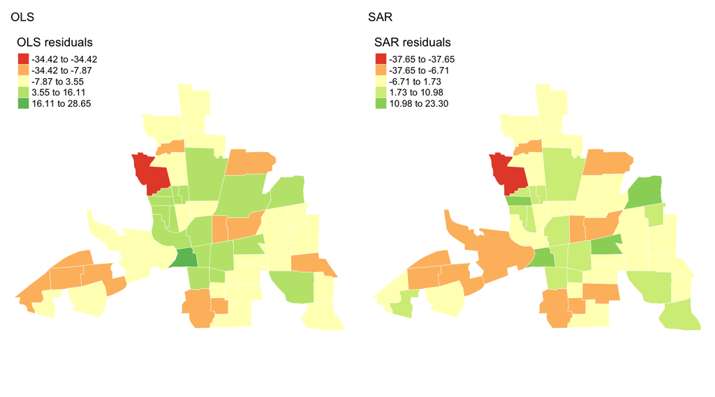

OLS vs. SAR residuals — note the reduction in spatial clustering in the SAR model.

```r
columbus$resid_ols <- residuals(reg1)
columbus$resid_sar <- residuals(reg3)

p_ols <- tm_shape(columbus) +
  tm_fill("resid_ols",
          style = "jenks", n = 5,
          palette = "RdYlGn", midpoint = 0,
          title = "OLS residuals") +
  tm_borders(col = "white", lwd = 0.4) +
  tm_layout(main.title = "OLS", main.title.size = 0.9, frame = FALSE,
            legend.outside = FALSE)

p_sar <- tm_shape(columbus) +
  tm_fill("resid_sar",
          style = "jenks", n = 5,
          palette = "RdYlGn", midpoint = 0,
          title = "SAR residuals") +
  tm_borders(col = "white", lwd = 0.4) +
  tm_layout(main.title = "SAR", main.title.size = 0.9, frame = FALSE,
            legend.outside = FALSE)

tmap_arrange(p_ols, p_sar, ncol = 2)
```

**Residual Moran’s I comparison:**

```r
moran_ols_resid <- moran.test(residuals(reg1), listw = queen_listw)
moran_sar_resid <- moran.test(residuals(reg3), listw = queen_listw)

cat("OLS residuals — Moran's I:", round(moran_ols_resid$estimate[1], 4),
    "  p =", round(moran_ols_resid$p.value, 4), "\n")
```

```
OLS residuals — Moran's I: 0.2221   p = 0.004
```

```r
cat("SAR residuals — Moran's I:", round(moran_sar_resid$estimate[1], 4),
    "  p =", round(moran_sar_resid$p.value, 4), "\n")
```

```
SAR residuals — Moran's I: 0.0331   p = 0.2733
```

## 8. Understanding Spillover Effects

One of the most important — and often overlooked — aspects of spatial regression is the distinction between **direct** and **indirect effects**.

### 8.1 The Feedback Problem

In the SAR model, a change in income in neighborhood A affects:

1. Crime in A directly (direct effect)
2. Crime in A’s neighbors (first-order spillover)
3. Crime in A’s neighbors’ neighbors — because they are affected by A’s neighbors (second-order spillover)
4. Eventually, crime in A itself — because A is affected by its neighbors, who are now affected (feedback effect)

This is why simple $\beta$ coefficients in the SAR model are uninterpretable. The `impacts()` function from `spatialreg` computes the full decomposition.

### 8.2 Visualizing the Impact Decomposition

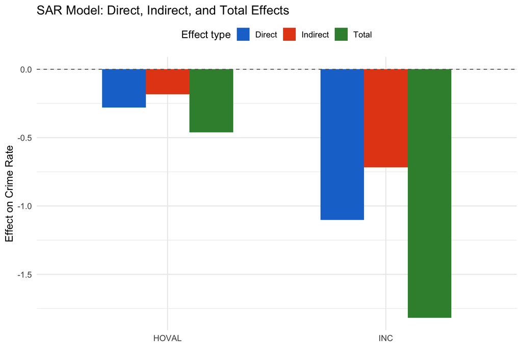

Direct vs. indirect effects for the SAR model. Indirect (spillover) effects can be substantial.

```r
impacts_sar <- impacts(reg3, listw = queen_listw, R = 500)

varnames <- attr(impacts_sar, "bnames")
direct   <- as.numeric(impacts_sar$res$direct)
indirect <- as.numeric(impacts_sar$res$indirect)
total    <- as.numeric(impacts_sar$res$total)

imp_df <- data.frame(
  Variable = factor(rep(varnames, 3)),
  Effect   = rep(c("Direct", "Indirect", "Total"), each = length(varnames)),
  Estimate = c(direct, indirect, total)
)

ggplot(imp_df, aes(x = Variable, y = Estimate, fill = Effect)) +
  geom_col(position = "dodge", width = 0.6) +
  geom_hline(yintercept = 0, linetype = "dashed", color = "grey40") +
  scale_fill_manual(values = c("Direct" = "#1976D2", "Indirect" = "#E64A19", "Total" = "#388E3C")) +
  labs(title = "SAR Model: Direct, Indirect, and Total Effects",
       x = NULL, y = "Effect on Crime Rate",
       fill = "Effect type") +
  theme_minimal(base_size = 13) +
  theme(legend.position = "top")
```

## 9. Conceptual Map of Spatial Models

|  | **No spatial lag in $y$** | **Spatial lag in $y$ ($\rho Wy$)** |
| --- | --- | --- |
| **No lag in $X$ or $u$** | OLS | SAR |
| **Lag in $X$ only** | SLX | SDM |
| **Lag in $u$ only** | SEM | SARAR |
| **Lag in $X$ and $u$** | SDEM | Manski (all-inclusive) |

Choosing among them is primarily a **theoretical** question — what do you believe is the data-generating process? — with LM tests as a useful empirical guide when theory is ambiguous.

## 10. Exercises

**Exercise 10.2 — Comparing Contiguity Structures**

Re-fit the SAR model using **rook** contiguity (`rook_listw`) instead of queen. Compare:

- The estimated $\rho$
- The direct and indirect effects
- The model AIC

What does this sensitivity tell you about the importance of the weights matrix choice?

**Exercise 10.3 — Spillover Interpretation**

Using the SDM impacts output, interpret the **indirect effect** of `INC` (household income). Write 2–3 sentences suitable for inclusion in a policy brief: what does the spillover mean in plain language, and what policy implication might follow?

## 11. Discussion Questions

1. **Theory before models**: A colleague says, “I’ll just run all eight models and pick the one with the best AIC.” What is the problem with this approach, and what should guide model selection instead?
2. **Spillovers and policy**: You find a significant *indirect* effect of neighborhood poverty on crime, meaning high poverty in one area increases crime in *neighboring* areas. What does this imply for place-based policy interventions (e.g., targeted poverty reduction in one neighborhood)?
3. **The weights matrix as a model assumption**: We treated queen contiguity as given, but spatial weights encode a theoretical claim about the nature of spatial interaction. What alternative weight structures might make sense for studying (a) infectious disease transmission, (b) alcohol availability and harm, (c) emergency response times?
4. **Spatial error vs. spatial lag**: In a study of opioid overdose deaths at the county level, would you expect spatial dependence to manifest more in the *outcome* (SAR) or in the *error* (SEM)? What mechanisms would drive each?

## References

- Anselin, L. (1988). *Spatial Econometrics: Methods and Models.* Dordrecht: Kluwer Academic.
- Anselin, L. (2003). Spatial externalities, spatial multipliers, and spatial econometrics. *International Regional Science Review*, 26(2), 153–166.
- Burkey, M.L. (2010). Geographic Access and Demand in the Market for Alcohol. *The Review of Regional Studies*, 40(2), 159–179.
- LeSage, J.P. & Pace, R.K. (2009). *Introduction to Spatial Econometrics.* Boca Raton: CRC Press.
- Pace, R.K. & LeSage, J.P. (2008). A spatial Hausman test. *Economics Letters*, 101(3), 282–284.
- Ward, M.D. & Gleditsch, K.S. (2008). *Spatial Regression Models.* Thousand Oaks: SAGE.